[figure not shown]

**By:JC**

# **数据挖掘第一章-导论**

[figure not shown]

# 前情提要：轻代码、重思想、重算法

## 一：为什么我们需要数据挖掘

数据挖掘是一种从大量数据中自动发现有用信息的过程。  
随着数据的增长和复杂性的增加，数据挖掘变得越来越重要。  
现实生活的数据中隐含着许多有价值的信息，但是这些信息需要我们去以各种手段去挖掘并且呈现出来。  
在向别人呈现工作的时候你不可能给人excel数据让人去看一列列的数字。

1. 揭示潜在模式

数据挖掘可以帮助我们发现数据中隐藏的潜在模式。通过分析大量数据，我们可以识别有趣的、非显然的关系，从而揭示数据中的潜在模式。  
这些模式可以用于优化业务决策、开发新产品和改进现有产品等方面。  
经典案例：沃尔玛超市管理人员分析其销售数据时发现“啤酒”与“尿布”这两件商品会出现在美国消费者的同一个购物篮中。  
2. 预测未来趋势  
通过数据挖掘，我们可以利用历史数据来预测未来趋势。这对于业务决策、市场研究和资源分配等方面非常有用。  
经典案例：机器学习中的股价预测、银行贷款违约预测...  
3. 发现异常  
数据挖掘可以帮助我们发现数据中的异常值和离群值。这对于识别欺诈、检测错误和发现异常行为等方面非常有用。  
4. 提高效率：  
数据挖掘可以帮助我们自动化和优化决策过程，从而提高效率和准确性。通过使用数据挖掘技术，我们可以自动化分析过程，发现隐藏的模式，  
识别规律，并在不需要人工干预的情况下提供决策支持。  
5. 优化资源分配  
通过数据挖掘，我们可以了解消费者和市场的行为和趋势，从而优化资源的分配。例如，一个公司可以使用数据挖掘技术来了解其消费者的偏好  
和购买模式，从而调整产品线和制定更有效的市场营销策略。  
6. 改善客户体验  
通过数据挖掘，我们可以了解消费者的偏好和行为，从而提高客户体验。  
7. 探索新的机会  
数据挖掘可以帮助我们发现新的商业机会。通过分析市场趋势、消费者行为和竞争情况等，  
我们可以了解市场上的未满足需求和新的商业机会，从而为公司的未来发展提供支持。

## 二：如何进行数据挖掘/数据挖掘的步骤

1. 业务理解或问题定义

确定研究目标和需要解决的问题。这一步需要明确问题的定义、目标和假设等。  
2. 数据采集  
收集与问题相关的数据。可以使用现有数据源，例如企业内部数据库、公共数据库、社交媒体等，也可以通过在线调查、实验室测试等方法采集数据。  
3. 数据处理  
数据预处理、特征工程、数据集划分等等。后面章节细讲  
4. 建立模型  
选择合适的模型，建立数据挖掘模型。常用的模型包括决策树、神经网络、支持向量机、朴素贝叶斯等。  
使用训练集训练模型。在训练过程中，需要根据训练集调整模型参数，以提高模型的准确性和泛化能力。  
使用测试集评估模型的准确性和泛化能力。常用的评估指标包括准确率、召回率、精确度、F1值等。（评估）  
5. 模型优化  
在模型评估的基础上，优化模型以提高模型的准确性和泛化能力。常见的优化方法包括参数调整、特征选择和模型集成等。  
提高模型在实际场景的应用能力。  
6. 模型部署  
用数据库或者大数据开发的技术把模型部署到实际场景中。

## 模式识别

有10000个购物篮子

从纯数量出发： 购物篮子：[啤酒， 尿布， xxxx, xxxx, xxxx, xxxx...] -- 1000个人

或者从贝叶斯公式的角度出发： 啤酒出现在购物篮子之后，尿布出现的概率超过了60%。

## 机器学习：分类与回归

股价预测 --- 预测涨跌、预测明天股价多少钱、预测多久能涨价

[figure not shown]

银行违约 --- 区分好坏用户精准放贷

[figure not shown]

房价预测 --- 房子的户型、大小、区位、采光等等因素，预测房子的价格

[figure not shown]

我们的数据挖掘课程基本其实就是在学习诸多机器学习的算法

# **数据挖掘第二章-数据预处理**

[figure not shown]

## 一：认识数据

### 1.1 分类型数据 / 标称数据

分类数据（Category data）也称为标称数据（Nominal data），是一种非数字的数据，它描述了不同类别之间的关系。  
标称数据中的每个值都表示一种类别或标签，而不是数量或度量。  
标称数据通常包括有限的、不同的、固定的可能取值。  
例如，性别、国籍、颜色等都是标称数据。  
标称数据不具有可比性，不能进行算术运算或统计分析，但它们可以进行计数、比较和分类。  
在数据挖掘中，分类数据通常需要进行编码，以便于计算机处理和分析。  
常用的编码方法包括哑变量编码、二进制编码、计数编码、目标编码、独热编码等等。

案例:  
{"红色"：1， "蓝色"：2， "绿色"：3} 多分类  
{"男"：0， "女"：1} 二分类  
{"C级"：1， "B级"：2， "A级"：3， "S级"：4} 序数分类 存在大小关系

[figure not shown]

### 1.2 连续性变量

连续性变量（Continuous variable）是一种数量型数据类型，通常用来表示在一个范围内的任意值。  
连续性变量通常是数值型的，可以是实数、分数、比率等。与标称数据不同，连续性变量可以进行数学运算和统计分析。  
在数据挖掘中，连续性变量通常需要进行离散化处理，以便于计算机处理和分析。  
离散化是将连续性变量转换为离散型变量的过程。离散化方法包括等宽离散化、等频离散化、K-means离散化等。  
在机器学习竞赛中，归一化、标准化、均值编码等等也是经常采用的处理手段。  
数值型变量通常用来表示数量、度量或计数，例如年龄、身高、体重、温度、股票价格、收益率等。  
在医疗保健领域，连续性变量通常用于测量病人的生理指标，如血压、体温等，以便于对病情进行诊断和治疗。  
在金融领域，连续性变量通常用于测量财务指标，如股票价格、收益率等，以便于进行风险评估和投资决策。

### 1.3 其他类型数据

时间类型数据  
文本类型数据  
图片数据  
语音数据  
视频数据  
...

## 二： 数据预处理方法

### 2.1 缺失值填补

在数据挖掘过程中，由于数据收集或者处理过程中的各种原因，数据集中往往会存在一些缺失值。  
缺失值可能会对数据分析和建模带来一定的困扰，因此需要对缺失值进行填补。

1. 删除带有缺失值的行或列：对于缺失值比例较大的行或列，我们可以选择将其删除。  
   但是，这种方法会减少数据量，可能会影响分析结果。
2. 插值法：插值法是一种基于已有数据点的插值方法，即通过现有的数据来推算缺失值。常用的插值方法包括线性插值、拉格朗日插值、牛顿插值等。  
   插值法的优点是可以使用现有的数据来填补缺失值，但是缺点是需要一定的数学基础和计算量，而且如果数据中存在离群点，插值方法可能会失效。
3. 众数/平均数填充：对于分类变量可以使用众数来填充，对于数值型变量可以使用平均数来填充。  
   这种方法简单易行(新手狂喜)，但是可能会导致数据偏差，特别是当缺失值比例较大时。
4. 模型填充：模型填充是使用机器学习模型来预测缺失值。对于分类变量可以使用分类模型，对于数值型变量可以使用回归模型。  
   这种方法可以利用现有数据中的关系来填充缺失值，但是需要更多的计算资源和时间，而且可能会受到模型选择和数据质量的影响。

[figure not shown]

### 2.2 可视化工具

[figure not shown]

当我们进行数据分析时，经常需要使用柱状图、散点图等可视化图形来帮助我们更好地理解数据的分布和关系。

1. 柱状图：柱状图通常用来显示离散的类别变量之间的比较，例如不同销售区域的销售额、不同年份的收益等。  
   柱状图通常是一列或多列垂直排列的长方形，每个长方形的高度表示该类别的数量或总数。  
   柱状图可以帮助我们比较不同类别之间的数量差异，同时也可以很好地呈现数据的趋势。
2. 散点图：散点图通常用来显示两个连续变量之间的关系，例如身高和体重、广告投入和销售额等。  
   散点图由许多散点组成，每个散点的位置表示两个变量的值。散点图可以帮助我们发现数据中的趋势和规律，同时也可以发现异常值和离群点。
3. 折线图：折线图通常用来显示时间序列数据或连续变量的趋势，例如公司收益随时间的变化、气温的变化趋势等。  
   折线图由许多点和连接它们的线组成，每个点的位置表示一个时间点或连续变量的值。  
   折线图可以帮助我们发现数据的趋势和周期性，同时也可以预测未来的变化趋势。
4. 饼图：饼图通常用来显示不同类别之间的比例关系，例如不同产品的市场占有率、不同部门的预算占比等。  
   饼图由一个圆形和分割它的扇形组成，每个扇形的面积表示该类别的比例。饼图可以帮助我们更直观地了解不同类别之间的比例关系。

### 2.3 数据度量指标

中心趋势度量指标是用来描述数据集中趋向于哪个数值的一类统计量,常见的中心趋势度量指标有平均数、中位数和众数。

1. 平均数

是将数据集中的所有数值加起来，然后除以数据集中的数据个数。平均数的计算方法是将数据集中的所有数值加起来，然后除以数据集中的数据个数。
平均数受到极值的影响较大，所以在数据集有极值存在的情况下，中位数和众数更适合作为中心趋势度量指标。
$$\bar{x} = \frac{1}{n}\sum_{i=1}^{n} x_i$$
2. 中位数
中位数是将数据集中的数值按从小到大的顺序排列，然后取中间位置的数值。
如果数据集中的数据个数为偶数，则中位数为中间两个数的平均值。
$$\mathrm{Q}_{\frac{1}{2}}(x)=\left\{\begin{array}{ll} x_{\frac{n+1}{2}}^{\prime}, & \text { if } n \text { is odd. } \\ \frac{1}{2}\left(x_{\frac{n}{2}}^{\prime}+x_{\frac{n}{2}+1}^{\prime}\right), & \text { if } n \text { is even } \end{array}\right.$$
3. 众数
众数是数据集中出现次数最多的数值。如果数据集中有多个数值的出现次数相同，那么这些数值都是众数。
如果数据中有一个众数就是单峰分布或者单模态分布，两个就是双峰分布或者双模态分布。
$$\text{mode} = \arg \max_x \sum_{i=1}^{n} [x_i = x]$$

数据发散程度指标是指数据集中各个数据之间的差异或变化的程度。在数据挖掘中，常用以下指标来描述数据的发散程度:

1. 方差（Variance）

方差衡量数据分布的离散程度，即每个数据与数据集平均值的差的平方的平均值。方差越大，表示数据分布的离散程度越大，反之亦然。
方差可以用于消除连续型变量的量纲。
$$s^2 = \frac{\sum_{i=1}^n (x_i - \bar{x})^2}{n-1}$$
2. 标准差（Standard Deviation）
标准差是方差的算术平方根，通常与均值一起使用来描述数据的分布。标准差较小表示数据分布较集中，反之则表示数据分布较分散。
$$s = \sqrt{\frac{\sum_{i=1}^n (x_i - \bar{x})^2}{n-1}}$$
3. 极差（Range）
极差是数据集中最大值和最小值之间的差。极差越大表示数据的分散程度越大，反之表示数据的分散程度越小。
$$R = x_{\max} - x_{\min}$$
4. 四分位差（Interquartile Range，IQR）
四分位差是将数据集按大小排序后，第三四分位数与第一四分位数之差。四分位差可以用来衡量数据的分布情况，
尤其是中心部分的离散程度，即中间 50% 的数据。
$$IQR = Q_3 - Q_1$$
5. 离散系数（Coefficient of Variation，CV）
离散系数是标准差除以均值的比值，用于衡量标准差相对于均值的大小。如果离散系数较小，则表示数据的分布较为集中；
如果离散系数较大，则表示数据的分布较为分散。
$$CV = \frac{s}{\bar{x}} \ $$

### 2.4 连续型变量的处理

连续型变量是指可以取到任意数值的变量，例如温度、身高、体重等等。对于连续型变量，常见的处理方法包括(还有很多方法)

1. 分箱（binning）

将连续变量离散化为有序分类变量。可以采用等宽分组、等频分组等方法。分箱可以帮助我们更好地理解数据，并且可以避免一些异常值的影响。
2. 标准化（standardization）
将连续变量的数值缩放到相同的范围内，通常是将数据转化为均值为 0，方差为 1 的正态分布。
标准化可以消除不同变量之间的量纲差异，便于比较和分析。
$$ x' = \frac{x-\mu}{\sigma} $$
3. 归一化（normalization）
将连续变量的值缩放到 [0,1] 范围内。可以采用最小-最大规范化方法或者 Z-Score 规范化方法等。
归一化可以消除不同变量之间的量纲差异，方便比较和分析。
$$ x' = \frac{x-x_{min}}{x_{max}-x_{min}} $$
4. 聚类（clustering）
将连续变量聚类成若干个类别，可以用于数据降维和分类。常见的聚类方法包括 K-Means 算法和层次聚类算法等。
...

**分箱法案例讲解**  
房屋价格：[80, 85, 90, 100, 110, 120]  
分箱法：分段规则 >>> [80,100)记为1，[100,110)记为2，[110,+inf)记为3  
则房屋价格就被映射为[1,1,1,2,3,3]  
分段规则可以不同，比如等频分箱和等宽分箱。

**标准化案例讲解**  
假设我们有一个包含房屋面积和房屋价格的数据集。其中  
房屋面积的均值为1500平方英尺，标准差为500平方英尺。  
房屋价格的均值为200000美元，标准差为50000美元。  
如果直接把两个量纲不同并且数值差异巨大的数值直接用模型进行分析，可能会使模型的效果变弱。  
例如$y=ax+by+c$，如果把这两个数值一起丢进模型，可能会造成价格对于y值的影响会偏大。  
因此我们想要对数据集进行标准化处理或者归一化，以便在后续的分析中能够更好地比较两个变量。  
假设数据集中有一条记录，房屋面积为1700方英尺，房屋价格为240000元。  
那么这条记录经过标准化后的结果为：

\begin{aligned} \text{标准化的房屋面积} &= \frac{1700 - 1500}{500} = 0.4 \\ \text{标准化的房屋价格} &= \frac{240000 - 200000}{50000} = 0.8 \end{aligned}

如果标准化的分数大的很离谱，比如100,200等等，就说明这个样本的数据可能是一个离群点，可以考虑删除等操作。

[figure not shown]

**归一化案例讲解**  
假设一份数据集有两个特征，分别为房屋面积和房屋价格  
面积： [60, 70, 80, 90, 100]  
价格： [500000, 600000, 700000, 800000, 900000]  
运用归一化公式：$x_i'=\frac{x_i-\min(x_i)}{\max(x_i)-\min(x_i)}$  
将数据转化为：  
面积： [0.0, 0.25, 0.5, 0.75, 1.0]  
价格： [0.0, 0.25, 0.5, 0.75, 1.0]

**归一化和标准化的区别和联系**  
**相同点：**  
都是对原始数据进行线性变换，旨在将数据转换为更适合分析的形式。  
都可以避免原始数据的量纲和单位对分析结果的影响。  
都可以使不同特征的权重具有可比性，有助于提高机器学习算法的精度和效率。  
**不同点：**  
标准化是将原始数据转换为标准正态分布，即均值为0，标准差为1，而归一化是将原始数据缩放到[0,1]区间内。标准化改变了数据的分布，而归一化没有。  
标准化考虑的是数据的分布情况，主要处理的是有明显上下界的数据；而归一化主要考虑的是对不同量级的特征进行比较，主要用于处理数据的量纲问题。  
标准化可能会受到异常值的影响，而归一化对异常值比较鲁棒。

### 2.5 分类型变量的处理

1. 标签编码（Label Encoding）

将每个类别映射为一个整数标签，从 0 开始，逐一增加。该方法不增加特征数量，但是有可能引入一些不必要的大小关系，不适合用于数值型特征。  
例如给定数据：[红色，蓝色，绿色]  
给定映射规则：红色=0，蓝色=1，绿色=2  
数据处理结果：[0, 1, 2]  
2. 统计量编码（Statistical Encoding）  
对于每个类别，计算它们在训练集中出现的频率或其他统计量，比如平均目标值、标准差等，将统计量作为特征值。  
统计量编码能够很好地利用类别信息，但是容易导致过拟合，需要进行正则化或者加噪声处理。 例如给定数据：[红色，蓝色，绿色, 红色]  
将颜色出现在数据中的频数作为对应的编码，红色出现两次，其余颜色出现一次  
则数据处理结果：[2, 1, 1, 2]  
其余的统计量编码类似这种思路。  
...

# **数据挖掘第三章-聚类算法**

[figure not shown]

## 一. 有监督学习和无监督学习

有监督学习和无监督学习是机器学习中两种常用的学习方式。  
有监督学习是指利用已知的带有标签的数据集去训练模型，然后通过该模型对未知数据进行预测.  
无监督学习则是指在没有标签信息的情况下，对数据集进行聚类、降维等操作，从中提取数据的内在结构和特征。

1. 有监督学习（supervised learning）

假设我们有一个分类问题，数据集中包含许多橙子和苹果的图片，我们需要训练一个模型，对新的水果图片进行分类。  
这是一个有监督学习的问题，因为我们已经知道了每张图片对应的类别（橙子或苹果）。  
在这个问题中，每张图片是一个样本，而橙子或苹果是该样本对应的标签。  
我们可以使用已知的带有标签的数据集，比如说100张图片（50张橙子，50张苹果），来训练模型。  
模型可以基于这些带有标签的数据学习出橙子和苹果的特征，然后对新的水果图片进行分类预测。  
相当于给定了数据向量$x$和标签$y$，然后利用算法产生模型$f()$，形成$f(x)$到$y$的映射关系。  
2. 无监督学习（unsupervised learning）  
假设我们有一个无标签的数据集，里面包含了许多房屋的信息，包括房屋的面积、价格、位置等等。  
我们想要对这些房屋进行聚类，找出相似的房屋。这是一个无监督学习的问题，因为我们没有标签信息，无法知道每个房屋的真实类别。  
在这个问题中，每个房屋是一个样本，样本之间的相似度需要通过一定的度量方式来衡量。  
我们可以使用聚类算法，比如k-means算法，对这些房屋进行聚类操作，将相似的房屋归为同一类。  
通过聚类，我们可以发现一些隐含在数据中的模式和结构，帮助我们更好地理解数据。

## 二. K-means算法

**数据样本**

假设一个房价数据集，记录了房子的价格和房子的面积，数据集中有100条记录。  
我们用 $x_i$ 来表示其中第 $i$ 行数据，具体数据为[1000, 100]。表明价格为1000，面积为100。  
$x_{i1}$和$x_{i2}$分别表示样本中的第一个特征和第二个特征，分别是1000,100。

**样本距离的定义**

假设一个样本有n个特征。

1. 欧式距离

欧式距离是最常用的样本距离度量方式。对于两个样本$x_i$和$x_j$，它们之间的欧几里得距离$d_{ij}$可以表示为：
$$d_{i j}=\sqrt{\sum_{k=1}^{n}\left(x_{i k}-x_{j k}\right)^{2}}$$ 2. 曼哈顿距离
曼哈顿距离也叫$L1$距离，它是指在坐标系上两点之间的距离，也就是两点在横坐标和纵坐标上的差的绝对值之和。
对于两个样本$x_i$和$x_j$，它们之间的曼哈顿距离$d_{ij}$可以表示为：
$$d_{ij} = \sum_{k=1}^n |x_{ik} - x_{jk}|$$
3. 切比雪夫距离
切比雪夫距离是指在坐标系上两点之间的距离，也就是两点在横坐标和纵坐标上的差的绝对值的最大值。
对于两个样本$x_i$和$x_j$，它们之间的切比雪夫距离$d_{ij}$可以表示为：
$$d_{i j}=\max _{k=1}^{n}\left|x_{i k}-x_{j k}\right|$$
4. 闵可夫斯基距离
闵可夫斯基距离是一种更一般化的距离度量方式，可以看做是欧几里得距离和曼哈顿距离的一般化。它可以表示为：
$$d_{ij}=(\sum_{k=1}^{n}(\left| x_{ik} - x_{jk}\right|)^{p})^{\frac{1}{p}}$$

**K-means算法目标函数**

K-means是一种基于距离的聚类算法，kmeans算法的目标函数通常被定义为所有数据点与它们所属簇中心点之间的平方误差之和。  
具体来说，对于一个数据集$X$，如果将它分成$k$个簇，每个簇的中心点分别为$c_1, c_2, ..., c_k$，则kmeans算法的目标函数可以表示为：  
K-means算法的目标函数为：$min J = \sum\limits_{i=1}^k\sum\limits_{x\in C_i}||x-c_i||^2$  
假设有第一个簇中只有两个样本$x_1$和$x_2$, $x_1 = [1, 2]$, $x_2 = [3, 4]$，则簇中心$c_1 = \frac{(x_1 + x_2)}{2 }= [2, 3]$

**K-means算法步骤**

算法的步骤可以概述为：

1. 首先随机选择K个中心点（簇的中心）。
2. 将每个数据点分配到离其最近的中心点所在的簇。
3. 然后，重新计算每个簇的中心点。
4. 将每个数据点重新分配到离其最近的新中心点所在的簇。
5. 重复这个过程，直到簇中心点不再变化或达到预设的迭代次数为止。

**K-means算法具体案例**

假设我们有一个包含4个样本的数据集，每个样本都有2个特征。  
我们的目的是利用k-means算法把样本聚成2类。

| x1 | x2 |
| --- | --- |
| 1 | 2 |
| 2 | 1 |
| 3 | 1 |
| 1 | 3 |

[output not shown]

然后重新计算簇的中心点，C1簇的中心点变成了[1.5, 1.5], C2簇的中心点变成了[2, 2]  
然后重新计算四个样本点到簇中心的距离并且按照距离分类。

| x1 | x2 | 到中心1的距离 | 到中心2的距离 | 暂时分类 |
| --- | --- | --- | --- | --- |
| 1 | 2 | 0.5 | 1 | C1 |
| 2 | 1 | 0.5 | 1 | C1 |
| 3 | 1 | 2.5 | 2 | C2 |
| 1 | 3 | 2.5 | 2 | C2 |

聚类结果不再发生变化算法结束。

**Tip**

1. 初始聚类中心的选择

K-means算法对初始聚类中心的选择非常敏感，不同的初始聚类中心可能会导致不同的聚类结果。  
因此，如果数据集的结构比较复杂，K-means可能需要多次尝试不同的初始聚类中心以获得更好的聚类结果。  
2. 对噪声和异常值比较敏感  
K-means算法对噪声和异常值比较敏感，这些值可能会导致算法产生错误的聚类结果。  
因此，在使用K-means算法之前，需要先进行数据清洗和异常值处理。  
3. 对非凸的数据集表现不佳  
K-means算法假定所有的数据点都在凸形空间中，因此对非凸的数据集表现不佳。  
当数据集的形状比较复杂，如存在环形簇或月牙形簇时，K-means算法可能会将这些簇分为多个簇。  
4. 需要指定聚类数量  
K-means算法需要事先指定聚类数量K，但在实际应用中，聚类数量往往不是事先已知的。  
因此，在使用K-means算法时，需要使用一些技术来确定最佳的聚类数量，如肘部法则和轮廓系数等。

## 三. K-modes算法

K-means算法在度量样本间距离的时候采用的是特征属性值的差异，特征值差异大距离就远。  
但是前面也说过分类型变量的数字仅仅是一个标签，不存在数量大小关系，因此这里提出了K-modes算法。

KMODES算法是一种基于频数表的聚类算法，适用于离散型数据的聚类问题。  
相较于KMEANS算法，它不需要计算数值型变量的平均值和方差，因此适用于离散型数据。  
该算法采用了基于频数表的聚类方法，即将离散型变量的每个可能取值作为聚类中心，然后计算样本与聚类中心的距离。  
最后将每个样本划分到距离最近的聚类中心所在的簇中。

**K-modes算法流程**

1. 初始化

选定聚类数 $K$，随机初始化 $K$ 个聚类中心。
2. 计算距离
计算每个样本与每个聚类中心之间的距离。假设样本有 $p$ 个分类型特征。
KMODES算法使用的距离度量方法是简单匹配系数，简单匹配系数是计算两个样本在同一列上取相同值的比例。
假设样本 $i$ 在属性 $j$ 上的取值为 $a_{ij}$，聚类中心 $k$ 在属性 $j$ 上的取值为 $b_{kj}$，则 $i$ 和 $k$ 之间的简单匹配系数为：
其中$\delta(红色, 绿色)=1$, $\delta(红色, 红色)=0$
$$SMC(i, k) = \frac{\sum_{j=1}^{p} \delta(a_{ij}, b_{kj})}{p} $$
3. 分配样本
对于每个样本，将其分配到距离最近的聚类中心所在的簇中。
4. 更新聚类中心
对于每个簇，计算该簇中每个属性上出现频率最高的值，作为该簇的新聚类中心。
5. 重复2 - 4步

**K-modes算法具体案例**

假设我们有如下数据集，然后想把数据集聚成两类。

| 商品A | 商品B |
| --- | --- |
| 服装 | 食品 |
| 电子 | 食品 |
| 服装 | 服装 |
| 电子 | 电子 |

从数据中随机选择两个样本作为初始簇中心：[服装, 食品], [电子, 电子]，然后计算每个样本到簇中心的距离。  
我偷懒直接算个数了(*^▽^*)，但是还是得按照公式算比例的哈。

[output not shown]

然后重新得到新的簇中心，C1[服装， 服装]， C2[电子， 电子]（因为只有一个，随机选一个就好了）  
然后重新计算样本到簇中心的距离，迭代计算直到聚类结果不发生变化为止。

## 四. K-prototype算法

K-prototype算法是一种聚类算法，可以用于处理同时包含离散型和连续型属性的数据集。
算法步骤和之前两个算法的步骤是一样的，只不过在计算样本距离时的公式不一样。
对于连续型变量采取欧氏距离等等计算公式，而对于分类型变量则采取简单匹配系数来计算距离，然后两个部分的数值加总。
其中 $\gamma$ 表示了分类型变量的不同在样本距离里的权重，如果 $\gamma$ 越大，那么分类型变量的不同对聚类结果的影响就越大。
$$d(x_{i}, x_{j}) = \sum_{k=1}^{p}(x_{ik} - x_{jk})^2 + \gamma \sum_{k=p+1}^{m}\delta(x_{ik}, x_{jk}) $$

## 五. 如何决定簇的数量

在聚类算法中，决定簇的数量是一个重要的问题，通常称为“簇的数目选择”或“簇的数量确定”问题。  
在思考这个问题时我们还是要回到最初的目标函数。  
K-means算法的目标函数为：$min J = \sum\limits_{i=1}^k\sum\limits_{x\in C_i}||x-c_i||^2$  
目标函数表达出来的意思是要让属于同一个簇的点到达簇中心的距离总和最小，即类内误差最小。  
然后把所有簇的距离总和全部加在一起，这个和我们称之为聚类误差（SSE）。

1. 手肘法

对于给定的数据集，通过绘制簇的数量和对应的聚类误差（SSE）的曲线来确定最佳簇的数量。当增加簇的数量时，SSE的下降率会变得越来越缓慢。  
找到曲线上的“肘部”，即SSE的下降速度开始变缓的位置，可以作为最佳簇数的选择。  
2. 轮廓系数法  
轮廓系数是用于评估聚类结果的一种度量，它考虑了簇的内部紧密度和不同簇之间的分离度。  
对于给定的聚类结果，轮廓系数越接近于1，表示聚类结果越合理。因此，可以通过计算不同簇数下的轮廓系数来选择最佳的簇数。  
3. 专家知识  
有时候，专家知识可以帮助确定最佳的簇数。例如，在医学研究中，医生可能已经知道某些疾病的分类，因此可以用这些信息来确定最佳的簇数。  
4. 经验法则  
根据经验，可以将数据集的大小作为簇的数量的指导。  
例如，对于较小的数据集，通常选择2-4个簇，对于较大的数据集，可以选择更多的簇。  
但这种方法需要结合实际情况进行调整，不一定适用于所有情况。

**可视化直观了解肘部法则**

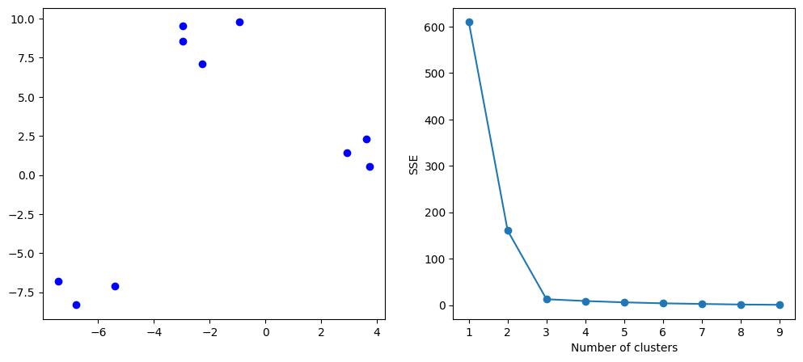

```python
import matplotlib.pyplot as plt
from sklearn.cluster import KMeans
from sklearn.datasets import make_blobs
import warnings
warnings.filterwarnings('ignore')

# 创建一个数据集，包含10个样本点，每个样本点有两个特征
X, y = make_blobs(n_samples=10, centers=3, n_features=2, random_state=42)

# 绘制样本点
plt.figure(figsize=(12,5))
plt.subplot(1,2,1)
plt.scatter(X[:, 0], X[:, 1], c='blue')

# 尝试不同的簇数，并计算相应的SSE
SSE = []
for k in range(1, 10):
    kmeans = KMeans(n_clusters=k)
    kmeans.fit(X)
    SSE.append(kmeans.inertia_)

# 绘制SSE与簇数的关系图
plt.subplot(1,2,2)
plt.plot(range(1, 10), SSE, marker='o')
plt.xlabel('Number of clusters')
plt.ylabel('SSE')
plt.show()
```

代码自动生成了10个样本，样本从图形上看很适合分成三类。  
根据聚类误差来看，当K从1到3变化时，聚类误差的下降速度非常快，但是当K从3到4时，SSE就没有发生明显的变化。  
因此根据肘部法则这个数据集更适合聚成3类。

## 六. 如何评价聚类算法的结果

1. 内部评价指标

这些指标基于聚类内部的数据分布，用于评估聚类算法的有效性和准确性。  
常用的内部评价指标包括轮廓系数、Calinski-Harabasz指数、Davies-Bouldin指数等。  
2. 外部评价指标  
这些指标基于已知的数据类别信息，如真实的类别标签，用于评估聚类算法的性能。常用的外部评价指标包括纯度、兰德指数、互信息等。  
3. 可解释性和可视化  
聚类算法不仅需要能够准确地将数据点分组，还需要对这些分组提供可解释的解释和可视化。  
4. 算法的可扩展性  
聚类算法应该能够处理大量数据，并且在处理大量数据时应该保持相对较快的运行速度。  
等待后面有时间了补充，聚类算法结果的评价很重要...  
同时还有很多改进版本的聚类算法还等待补充。

# **数据挖掘第四章-基本分类算法**

[figure not shown]

机器学习中的分类任务是一种监督学习任务，其目标是将输入数据分成预定义的几个类别中的一个或多个。  
在分类任务中，训练数据集包含了许多已经被标记了类别的样本数据，机器学习模型根据这些已知类别的样本数据来学习如何对未知数据进行分类。  
分类任务可以分为两类：二分类和多分类。

1. 二分类任务

这种任务将输入数据分为两个类别中的一个。例如，判断一封电子邮件是否是垃圾邮件或者是否是欺诈邮件。  
2. 多分类任务  
这种任务将输入数据分成多个类别中的一个。例如，图像识别问题中，将图像分类为人类、狗、猫或汽车等多个类别中的一个。

接下来就介绍几种机器学习中常见的分类算法。

## 一. KNN算法

K最近邻(K-Nearest Neighbors, KNN)是一种基于实例的监督学习算法，常用于分类和回归任务。  
KNN算法的基本思想是在训练数据集中找到与测试数据集最相似的K个样本，然后通过对这K个样本的类别进行投票来决定测试数据集的类别。  
KNN算法的优点是简单易懂、容易实现、适用于各种数据类型，例如离散型、连续型、多类别、多维度等。  
然而，KNN算法的缺点也很明显，首先需要大量的存储空间来存储训练数据集。  
其次计算距离是KNN算法的核心，需要对所有训练数据计算距离，计算复杂度较高。  
另外，在多维度空间中，KNN算法的距离计算也存在一定的问题，因为随着维度的增加，距离计算的效率和准确性都会受到影响。

[figure not shown]

**KNN算法步骤**  
计算待分类样本与训练数据集中每个样本之间的距离，常用的距离度量方法包括欧氏距离、曼哈顿距离等。  
选择与待分类样本距离最近的K个样本，这些样本被称为K个最近邻。  
根据K个最近邻的类别进行投票，将待分类样本归为投票得票最多的类别。K一般选择奇数。

**KNN算法案例**

假设我们有一个数据集，一共有5个样本，每个样本有2个特征，同时数据集还提供了标签数据y。

| x1 | x2 | y |
| --- | --- | --- |
| 1 | 1 | 0 |
| 2 | 2 | 0 |
| 3 | 3 | 1 |
| 4 | 4 | 1 |
| 5 | 5 | 1 |

这时候有一个没有标签的样本[6, 6]，需要我们判断一下这个样本属于哪一个类别。  
首先我们按照算法步骤，首先计算一下新样本与已知样本的距离，样本距离的度量采用欧式距离。

[output not shown]

第二步，我们设定K=3，即选出与新样本距离最近的3个样本，让进行投票决定。  
与新样本距离最近的三个样本分别是[3, 3]、[4, 4]、[5, 5]。对应的标签为1，1，1。  
按照少数服从多数的原则，最终投票决定新样本的标签为1。

| x1 | x2 | y |
| --- | --- | --- |
| 1 | 1 | 0 |
| 2 | 2 | 0 |
| 3 | 3 | 1 |
| 4 | 4 | 1 |
| 5 | 5 | 1 |
| 6 | 6 | 1 |

**TIP**

这里K的选定一般都是选择奇数个，因为偶数可能会出现数量相同的情况。  
K值在实际中一般取3、5、7、9，也有100以上的情况。  
在具体数据集中可以采用交叉验证的方法来确定K具体取多少能达到较优的分类效果。  
距离公式选定的不同也会影响投票的结果，需要根据实际数据合理选择距离公式。  
这里可以后续继续补充完整。

## 二. 朴素贝叶斯算法

朴素贝叶斯算法（Naive Bayes）是一种基于贝叶斯定理和特征条件独立假设的分类算法。  
它的基本思想是，在给定一个新的样本特征值后，根据贝叶斯定理计算出该样本属于每个类别的概率，然后选取概率最大的类别作为该样本的分类。

朴素贝叶斯算法的主要假设是特征条件独立性，即假设每个特征在给定类别的条件下是独立的，即：

$$P(X=x| Y=c)=\prod_{i=1}^{m}P(X_i=x_i|Y=c)$$

其中，$X_i$表示样本的第$i$个特征，$x_i$表示该特征对应的取值，$Y$表示类别，$c$表示类别的取值。举个具体的例子：

$$P(X=(1,2,3) |Y=1)=P(X_1=1|Y=1) * P(X_2=2|Y=1) * P(X_3=3|Y=1)$$

根据贝叶斯定理，我们可以计算出样本属于某个类别$c$的后验概率$P(Y=c|X)$：
$$P(Y=c|X)=\frac{P(X|Y=c)P(Y=c)}{P(X)}$$
其中，$P(X|Y=c)$表示在类别$c$的条件下，样本$X$出现的概率；$P(Y=c)$表示类别$c$的先验概率；$P(X)$表示样本$X$的概率。

由于$P(X)$对于每个类别都是相同的，因此可以省略，得到：
$$P(Y=c|X) \propto P(X|Y=c)P(Y=c)$$
但是在实际情况中, $P(X)$ 是一个归一化因子，可以让样本属于各个类的概率总和为1。后面结合案例细讲。

我们可以计算出在给定类别$c$的条件下，样本$X$的概率$P(X|Y=c)$：
$$P(X|Y=c) = \prod_{i=1}^{m}P(X_i=x_i|Y=c)$$

根据训练集中的数据，可以估计出$P(X_i=x_i|Y=c)$和$P(Y=c)$的值，进而计算出$P(Y=c|X)$的值，  
从而得到样本$X$属于每个类别的后验概率，选取概率最大的类别作为该样本的分类。

在实际应用中，我们通常使用对数似然来计算$P(X|Y=c)$：
$$-\log P(X|Y=c) = -\sum_{i=1}^{n} \log P(X_i=x_i|Y=c)$$
这样可以避免连乘运算带来的下溢问题。

**朴素贝叶斯算法案例**

给定如下数据集：

| 性别 | 电影类型 | 喜欢电影 |
| --- | --- | --- |
| 男 | 动作片 | 是 |
| 女 | 喜剧片 | 是 |
| 女 | 爱情片 | 是 |
| 男 | 动作片 | 是 |
| 男 | 爱情片 | 否 |
| 女 | 动作片 | 否 |
| 女 | 喜剧片 | 否 |
| 女 | 动作片 | 否 |
| 男 | 爱情片 | 否 |
| 男 | 动作片 | 否 |

现在要根据用户的性别和喜欢的电影类型（动作片、喜剧片、爱情片）来预测用户是否喜欢某个电影。  
给定一个样本[男性, 动作片]，利用朴素贝叶斯算法来判断这个样本属于哪一个类别。

1. 计算每个类别的先验概率$P(Y)$

**TIP**

朴素贝叶斯算法的优点包括

1. 算法简单

朴素贝叶斯算法是一种简单有效的分类算法，易于理解和实现。  
2. 适用性广泛  
朴素贝叶斯算法适用于大量特征的分类问题，例如文本分类、垃圾邮件过滤等。  
3. 可解释性强  
朴素贝叶斯算法能够给出每个特征对分类结果的贡献，因此具有很好的可解释性。

朴素贝叶斯算法的缺点包括

1. 假设特征独立

朴素贝叶斯算法假设各个特征之间相互独立，但实际情况往往不是这样，因此可能会影响分类效果。  
2. 对数据分布有要求  
朴素贝叶斯算法假设数据服从特定的分布，例如正态分布、多项式分布等，如果数据分布不符合假设，可能会导致分类效果下降。  
3. 处理连续特征需要离散化  
朴素贝叶斯算法处理连续特征需要先将其离散化，可能会导致信息损失和精度降低。

## 三. 决策树算法

决策树是一种常用的机器学习算法，可以用于分类和回归问题。  
它的主要思想是根据数据特征的不同，将数据集分割成多个小的子集，直到每个子集都只包含同一类别的数据，或者达到一定的停止条件。  
这样就可以构建出一棵树形结构，每个叶子节点表示一种类别或者一个回归值，每个中间节点表示一个特征及其取值范围。  
通过在树上从根节点到叶子节点的路径上进行特征判断，就可以对新数据进行分类或回归。

[figure not shown]

**决策树算法基本步骤**

1. 特征选择

从所有特征中选择一个最优特征，用于对数据集进行划分。常用的特征选择方法有信息增益、信息增益比、基尼指数等。  
2. 决策树的生成  
根据选定的特征进行数据集的划分，每个分支对应特征的一个取值，直到每个分支的样本都属于同一类别或者满足一定的停止条件为止。  
常用的停止条件包括树的深度、叶子节点中样本数的最小值等。  
3. 决策树的剪枝  
为了防止决策树出现过拟合现象，需要对决策树进行剪枝。  
常用的剪枝方法有预剪枝和后剪枝。预剪枝是在生成决策树时进行剪枝，后剪枝是在生成完整的决策树后再进行剪枝。

### 3.1 决策树的特征选择

回忆高中化学讲过的熵的概念，一个系统越混乱熵越大，越简洁熵越小。  
决策树的思想很明显是想让数据集分而治之，让整体数据集的分布更加简洁的。

**1. 信息增益**
信息增益（information gain）是一种常用的特征选择方法，它的基本思想是选择能够带来最大信息增益的特征作为划分依据。信息增益的定义如下：
$$ IG(D, f) = H(D) - H(D|f) $$
其中，$D$表示数据集，$f$表示特征，$H(D)$表示数据集$D$的经验熵，$H(D|f)$表示特征$f$对数据集$D$的经验条件熵。
经验熵$H(D)$的定义如下：
$$ H(D) = - \sum_{k=1}^{|y|} \frac{|C_k|}{|D|} \log_2 \frac{|C_k|}{|D|} $$
其中，$|y|$表示类别的个数，$|C_k|$表示属于第$k$个类别的样本数。
经验条件熵$H(D|f)$的定义如下：
$$ H(D|f) = \sum_{i=1}^n \frac{|D_i|}{|D|} H(D_i) $$
其中，$n$表示特征$f$的取值个数，$D_i$表示特征$f$取值为$i$的样本子集。
因此，特征$f$的信息增益$IG(D, f)$越大，则表明特征$f$越重要。

**信息增益计算案例**

给定数据，其中，Feature 1 和 Feature 2 是样本的两个特征，Label 是该样本的类别，0 表示负样本，1 表示正样本。：

[output not shown]

首先，计算数据集的熵：
$$H(D) = -\sum_{i=1}^{2}\frac{count(y=i)}{|D|}\log_2\frac{count(y=i)}{|D|}$$
其中，$count(y=i)$ 表示样本中类别为 $i$ 的数量，$|D|$ 表示样本总数。代入数据集，可以得到：
$$H(D) = -\frac{4}{7}\log_2\frac{4}{7} - \frac{3}{7}\log_2\frac{3}{7} \approx 0.985$$

[output not shown]

[output not shown]

**2. 信息增益比**
信息增益比是对信息增益的一种修正，信息增益倾向于选取那些特征取值非常多的特征作为划分节点，信息增益比克服了这种倾向。
它的基本思想是将信息增益除以特征$f$的固有值，以消除特征取值个数对信息增益的影响。
信息增益比的定义如下：
$$ IG_R(D, f) = \frac{IG(D, f)}{IV(f)} $$
其中，$IV(f)$表示特征$f$的固有值，定义如下：
$$ IV(f) = - \sum_{i=1}^n \frac{|D_i|}{|D|} \log_2 \frac{|D_i|}{|D|} $$
因此，特征$f$的信息增益比$IG_R(D, f)$越大，则表明特征$f$越重要。

**信息增益比计算案例**

[output not shown]

重点在于计算 $IV(Feature1)$ 和 $IV(Feature2)$  
$Feature1$ 一共有两种取值，分别是0和1,0的个数是3个，1的个数是4个，总共有7个样本。  
带入公式计算：  
$ IV(Feature1) = -(\frac{3}{7}\log_2\frac{3}{7} + \frac{4}{7}\log_2\frac{4}{7})$  
同理可以计算 $Feature2$ 的固有值。  
$ IV(Feature2) = -(\frac{3}{7}\log_2\frac{3}{7} + \frac{4}{7}\log_2\frac{4}{7})$

然后就可以继续计算信息增益比来决定选择哪一个特征是最优的划分特征。

**3. 基尼系数**
基尼指数是一种用于衡量数据集纯度的指标，它的定义如下：
$$Gini(p)=\sum_{k=1}^{K}p_k(1-p_k)$$
请读者自行推导：在二分类情况下基尼系数的写法。
其中，$p_k$ 是数据集中第 $k$ 类样本占总样本数的比例，$K$ 是分类数目。

在决策树算法中，基尼系数被用于选择最优划分特征，计算公式如下：
$$ Gini(D, a)=\sum_{v=1}^{V}\frac{|D^v|}{|D|}Gini(D^v) $$

[output not shown]

仍然是以该数据集来演示计算，首先计算整体数据集的基尼系数。

$$ Gini(D)=1-(\frac{3}{7})^2-(\frac{4}{7})^2=0.4898 $$

### 3.2 决策树的生成

基本的决策树生成算法有三种：ID3、C4.5、CART算法，算法内容可以参考以下博客。  
Reference: https://blog.csdn.net/kafei110/article/details/125585665

**ID3算法**  
ID3算法是一种经典的决策树算法，用于在给定数据集中生成决策树。该算法是基于信息熵和信息增益的原理进行特征选择，以对数据集进行划分。  
**ID3算法步骤**

1. 计算数据集中每个特征的信息增益，选择信息增益最大的特征作为当前节点的分裂特征。
2. 根据分裂特征，将数据集分为若干个子集，对每个子集递归地执行步骤1和步骤2，直到满足迭代停止的条件为止。
3. 最终生成的决策树可以通过遍历决策树对新样本进行分类。

对于ID3算法不再提供具体的算例了，后面时间充裕可以补充一个例子。  
简单的说明一下ID3算法，首先第一步的时候根据信息增益来选择特征肯定很简单了。  
第一步结束后，我们就可以根据选择的特征画出第一层的决策树。  
在画出第一层决策树后，决策树的每一个叶子节点上都分布了不同数量的数据集。  
然后在生成第二层决策树的时候，数据集就变成了每一个叶子节点上的数据集了，对叶子节点上的小数据继续用信息增益的法则进行分裂。  
还有一个细节就是根据ID3算法生成出来的决策树不是二叉树，多少叉取决于我们选择出来的特征，比如三叉四叉都有可能。

**C4.5算法**  
C4.5算法是决策树算法中的一种，与ID3算法相似，但对ID3算法中的一些问题进行了改进，是一种更为高级的决策树算法。  
C4.5算法在ID3算法的基础上进行了以下改进

1. 处理缺失值

C4.5可以处理缺失值，而ID3无法处理缺失值。当样本在某个特征上缺失值时，C4.5会按照该特征在所有样本中出现的概率随机赋值。  
2. 采用信息增益比  
C4.5采用信息增益比来选择最优特征，而不是仅仅使用信息增益，信息增益比可以对可取值数目多的特征进行惩罚。  
3. 连续值处理  
C4.5可以处理连续值特征，它会通过二分法将连续值离散化。  
**C4.5算法步骤**

1. 使用信息增益比（gain ratio）来度量每个特征的重要性，选择信息增益比最大的特征作为当前节点的分裂特征。
2. 根据分裂特征将数据集分为不同的子集，递归生成子树。
3. 使用交叉验证来判断是否剪枝，避免决策树过拟合。
4. 决策树输出：输出生成的决策树模型。